# Análisis de Regresión Lineal: Mantenimiento y Utilidad

Concurso Docente - Simulación Práctica

23 de noviembre de 2025

# 🛠️ Introducción: Relación entre Mantenimiento y Utilidad

Este análisis examina la relación lineal entre el **Gasto en Mantenimiento (X)** y la **Utilidad Obtenida (Y)** en miles de pesos, para una empresa del sector agroindustrial en Córdoba.  
El objetivo es estimar si mayores niveles de mantenimiento están asociados con mayores niveles de utilidad.

# 📥 Carga y Visualización de Datos (N = 30)

Las variables corresponden a 30 observaciones mensuales.

```r
# Variable Independiente (X): Mantenimiento (Miles ARS)
Mantenimiento_X <- c(
    15, 18, 20, 14, 16, 19, 23, 27, 30, 17,
    22, 25, 28, 31, 34, 30, 26, 21, 24, 18,
    35, 38, 40, 32, 36, 39, 37, 33, 29, 25
)

# Variable Dependiente (Y): Margen de Utilidad (Miles ARS)
Utilidad_Y <- c(
    82, 88, 95, 80, 85, 92, 105, 124, 134, 86,
    108, 117, 127, 135, 144, 132, 120, 102, 115, 90,
    155, 165, 170, 142, 160, 168, 162, 148, 128, 118
)

# Crear el dataframe
datos_empresa <- data.frame(Mantenimiento_X, Utilidad_Y)

# Ver las primeras filas
head(datos_empresa)
```

```
##   Mantenimiento_X Utilidad_Y
## 1              15         82
## 2              18         88
## 3              20         95
## 4              14         80
## 5              16         85
## 6              19         92
```

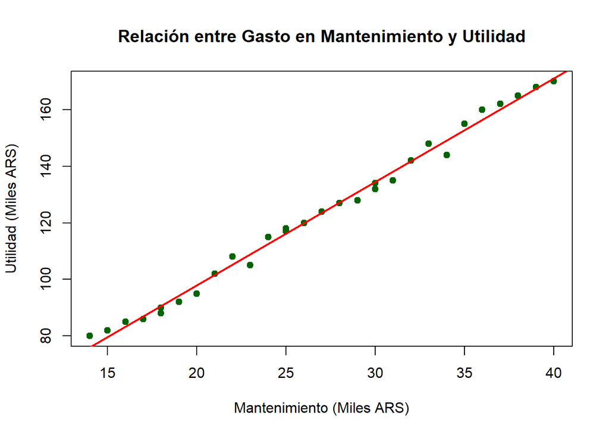

```r
plot(datos_empresa$Mantenimiento_X, datos_empresa$Utilidad_Y,
main = "Relación entre Gasto en Mantenimiento y Utilidad",
xlab = "Mantenimiento (Miles ARS)",
ylab = "Utilidad (Miles ARS)",
pch = 19,
col = "darkgreen")

# Agregar línea de regresión

abline(lm(Utilidad_Y ~ Mantenimiento_X, data = datos_empresa),
col = "red", lwd = 2)
```

```r
# Ajuste del modelo

modelo_rls <- lm(Utilidad_Y ~ Mantenimiento_X, data = datos_empresa)

# Resumen completo del modelo
summary(modelo_rls)
```

```
##
## Call:
## lm(formula = Utilidad_Y ~ Mantenimiento_X, data = datos_empresa)
##
## Residuals:
##     Min      1Q  Median      3Q     Max
## -5.1132 -1.9946  0.2857  1.8868  3.9506
##
## Coefficients:
##                 Estimate Std. Error t value Pr(>|t|)
## (Intercept)     24.90469    1.60177   15.55 2.65e-15 ***
## Mantenimiento_X  3.65319    0.05764   63.38  < 2e-16 ***
## ---
## Signif. codes:  0 '***' 0.001 '**' 0.01 '*' 0.05 '.' 0.1 ' ' 1
##
## Residual standard error: 2.397 on 28 degrees of freedom
## Multiple R-squared:  0.9931, Adjusted R-squared:  0.9928
## F-statistic:  4017 on 1 and 28 DF,  p-value: < 2.2e-16
```

# 🔮 Predicción de Utilidad para un nivel dado de Mantenimiento dado

Ejemplo: predecir la utilidad esperada si el gasto en mantenimiento es 40 mil pesos. ARS: Ŷ = 171.03 mil ARS

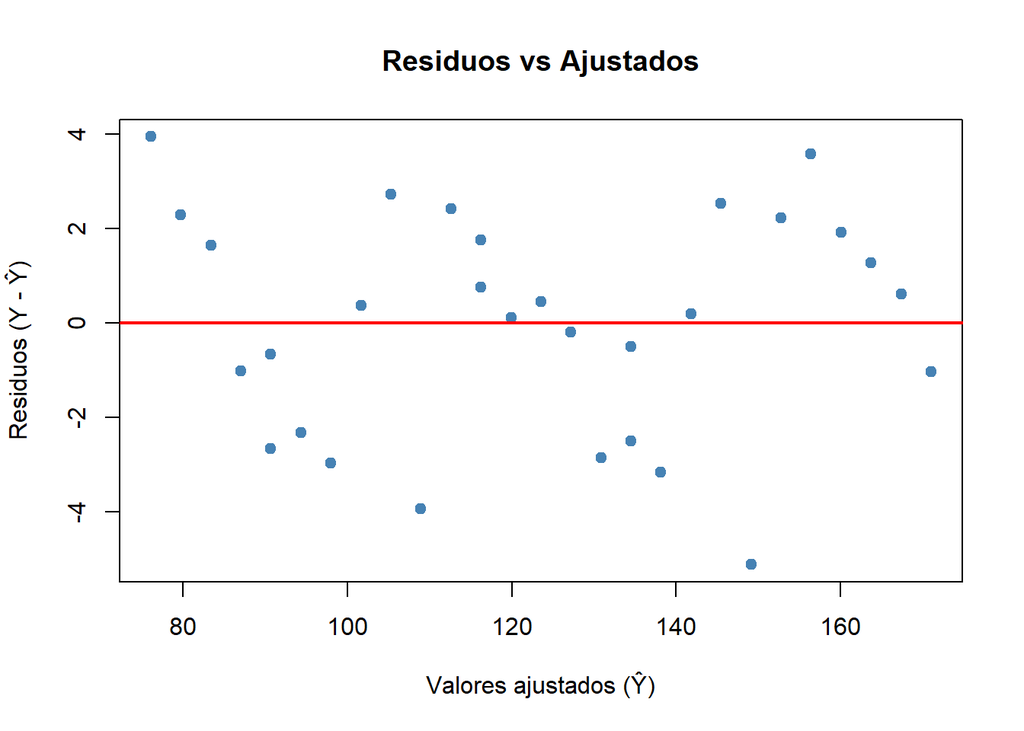

```r
# ============================================
# 🔍 Análisis de Errores (Residuos)
# ============================================

residuos <- resid(modelo_rls)
ajustados <- fitted(modelo_rls)

# Gráfico residuos vs ajustados
plot(ajustados, residuos,
     pch = 19, col = "steelblue",
     main = "Residuos vs Ajustados",
     xlab = "Valores ajustados (Ŷ)",
     ylab = "Residuos (Y - Ŷ)")
abline(h = 0, col = "red", lwd = 2)
```

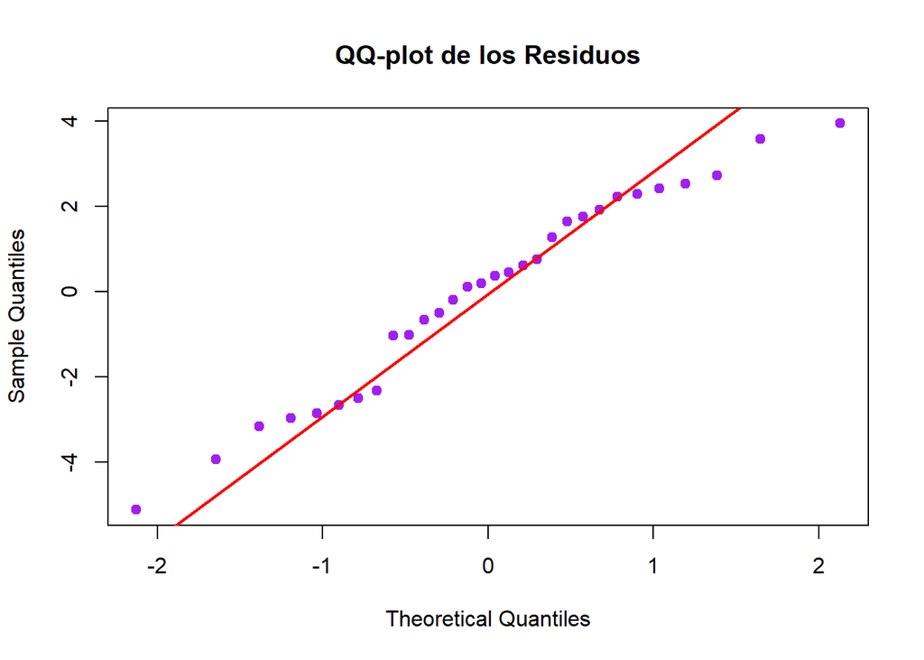

```r
# QQ-plot (normalidad aproximada)
qqnorm(residuos, pch = 19, col = "purple",
       main = "QQ-plot de los Residuos")
qqline(residuos, lwd = 2, col = "red")
```

```r
summary(residuos)
```

```
##    Min. 1st Qu.  Median    Mean 3rd Qu.    Max.
## -5.1132 -1.9946  0.2857  0.0000  1.8868  3.9506
```

```r
# ============================================
# 📏 Intervalo de Confianza para β1
# ============================================

IC_b1 <- confint(modelo_rls, "Mantenimiento_X", level = 0.95)
IC_b1
```

```
##                    2.5 %   97.5 %
## Mantenimiento_X 3.535128 3.771254
```

```r
# ============================================
# 🎯 Intervalo para la Media Condicionada en X = 40
# ============================================

X0 <- data.frame(Mantenimiento_X = 40)
pred_40 <- predict(modelo_rls, X0, se.fit=TRUE)

t_crit <- qt(0.975, df = nrow(datos_empresa) - 2)

IC_media_40 <- pred_40$fit + c(-1,1) * t_crit * pred_40$se.fit
IC_media_40
```

```
## [1] 169.2276 172.8371
```

```r
# ============================================
# 🚀 Intervalo de Predicción para un valor NO incluido en la base
# Ejemplo: X = 45
# ============================================

X_new <- data.frame(Mantenimiento_X = 45)

pred_new <- predict(modelo_rls, X_new, se.fit=TRUE)

sigma <- summary(modelo_rls)$sigma

EP_pred <- sqrt(pred_new$se.fit^2 + sigma^2)

IC_pred_new <- pred_new$fit + c(-1,1) * t_crit * EP_pred
IC_pred_new
```

```
## [1] 183.8607 194.7359
```